# Introduction to Classification

```r
library(tidyverse)
library(ISLR)
library(broom)
library(caret)
library(ROCR)
```

# Introduction

Recall the iris data set:

```r
head(iris)
```

|  | Sepal.Length | Sepal.Width | Petal.Length | Petal.Width | Species |
| --- | --- | --- | --- | --- | --- |
| 1 | 5.1 | 3.5 | 1.4 | 0.2 | setosa |
| 2 | 4.9 | 3.0 | 1.4 | 0.2 | setosa |
| 3 | 4.7 | 3.2 | 1.3 | 0.2 | setosa |
| 4 | 4.6 | 3.1 | 1.5 | 0.2 | setosa |
| 5 | 5.0 | 3.6 | 1.4 | 0.2 | setosa |
| 6 | 5.4 | 3.9 | 1.7 | 0.4 | setosa |

Attempting to predict the species of a flower based on the length and width measurements is a **classification** problem. In this case, the reponse variable assumes one of three possible class values: setosa, virginica, or versicolor. Let’s look at the reponse variable:

```r
table(iris$Species)
```

```
    setosa versicolor  virginica
        50         50         50
```

This is a multi-class classification problem since there are more than two distinct classes in wich observations may fall.

There is a special type of classification problem, **binary classification** where the categorical response variable takes values from just two distinct possible outcomes. There is a standard regression method for binary classification called logistic regression. Since regression is already a familiar concept, we will begin by discussing logistic regression, how it is implemented in R, and how to apply it.

# Logistic Regression

Consider the Default data set from the ISLR package:

```r
?Default
```

```r
dim(Default)
```

```
[1] 10000     4
```

```r
head(Default)
```

|  | default | student | balance | income |
| --- | --- | --- | --- | --- |
| 1 | No | No | 729.5265 | 44361.625 |
| 2 | No | Yes | 817.1804 | 12106.135 |
| 3 | No | No | 1073.5492 | 31767.139 |
| 4 | No | No | 529.2506 | 35704.494 |
| 5 | No | No | 785.6559 | 38463.496 |
| 6 | No | Yes | 919.5885 | 7491.559 |

```r
table(Default$default)
```

```
  No  Yes
9667  333
```

Let’s consider a simple problem. Can we use the average balance that the customer has remaining on their credit card after making their monthly payment (balance variable) to predict if a customer will default on their loan or not?

Let’s start with some visualizations:

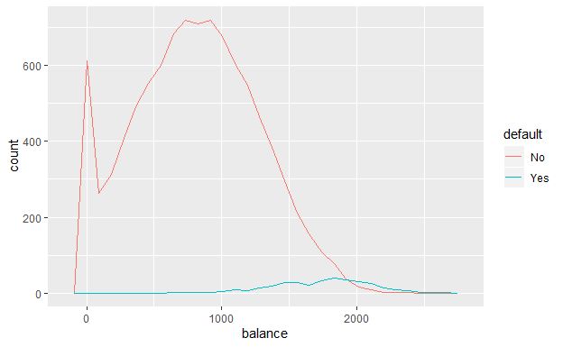

```r
Default %>% ggplot(aes(x=balance,color=default)) + geom_freqpoly()
```

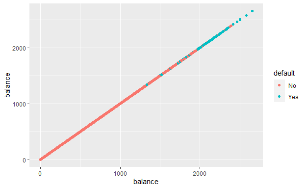

```r
Default %>% ggplot(aes(x=balance,y=balance,color=default)) +
 geom_point()
```

**Question:** What do these plots tell us?

We will make one more plot that may be helpful by first converting the default variable into a numerical variable that takes on either 0 (for No) or 1 (for Yes).

```r
Default_to_fit <- Default %>% mutate(default_num=ifelse(default == "Yes",1,0))
```

Consider the following plot:

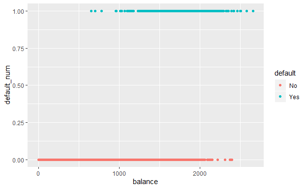

```r
Default_to_fit %>% ggplot(aes(x=balance,y=default_num,color=default)) +
 geom_point()
```

**Question:** What does this plot show?

We will see how logistic regression can be used to model this problem. We start with the R implementation and then explain the mathematical details afterward. The basic idea is that rather than modeling the response $Y$ directly, logistic regression models the probability that $Y$ belongs to a particular category.

We will start by creating a training and test set:

```r
train_ids <- createDataPartition(Default_to_fit$default_num,p=0.75,list=F)

Default_train <- Default_to_fit[train_ids, ]

Default_test <- Default_to_fit[-train_ids, ]
```

Let’s look at the respective sizes of the two sets:

```r
(dim(Default_train))
```

```
[1] 7500    5
```

```r
(dim(Default_test))
```

```
[1] 2500    5
```

The R implementation of logistic regression is done by the function glm() (generalized linear model) with the family arugment set to binomial. We will explain the reasons for this later.

```r
default_glm_mod = train(
 form = default ~ balance,
 data = Default_train,
 trControl = trainControl(method = "repeatedcv", number = 10,repeats = 5),
 method = "glm",
 family = "binomial"
)
```

We can examine some of the resulting output:

An assessment of the performance is shown with:

```r
default_glm_mod$results
```

|  | parameter | Accuracy | Kappa | AccuracySD | KappaSD |
| --- | --- | --- | --- | --- | --- |
| 1 | none | 0.9722665 | 0.3792861 | 0.003024552 | 0.09868254 |

and the best model is:

```r
default_glm_mod$finalModel
```

```
Call:  NULL

Coefficients:
(Intercept)      balance
 -10.561545     0.005426

Degrees of Freedom: 7499 Total (i.e. Null);  7498 Residual
Null Deviance:      2165
Residual Deviance: 1193     AIC: 1197
```